# Bayesien

Laurent Tavernier

# 1 DataSet

## 1.1 Présentation du dataset

Chaque observation donne des informations sur le nombre de points nécessaires (Barre) pour obtenir une mutation afin d’enseigner la matière indiquée (Matiere) dans le lycée renseigné (Ville, etablissement, commune) ainsi que des informations quantitatives sur l’établissement (effectif, taux de réussite, taux d’accès) en fonction du niveau d’études.

A noter:

- Plusieurs établissements portent le même nom mais sont dans des villes différentes. Nous utiliserons la variable “code_etablissement” pour identifier les établissements dans la suite de l’étude.
- Pour chaque ville il n’existe qu’un code postal. Nous pourrons donc travailler avec une seule des deux variables dans le modèle.
- Les lycées ne disposent pas tous des informations sur les mêmes matières
- Nous avons identifié des doublons dans les données. Nous avons donc décidé de les retirer de l’analyse
- les matières ne sont pas toutes présentents dans les mêmes proportions et de la même façon dans les établissements

Le dataset donne des informations pour 35 matières (Matiere) et 107 établissements (code_etablissement)

## 1.2 Analyse des variables

analysons tout d’abord la corrélation entre les variables

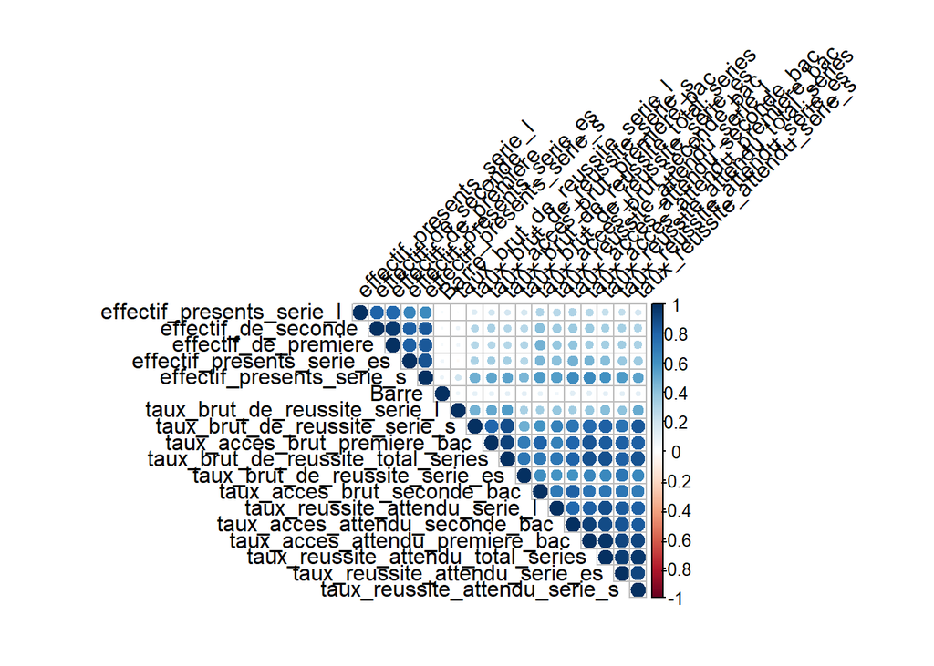

- Au sein d’un même établissement, les effectifs des classes supérieures sont liés aux effectifs des classes inférieures
- Le taux de réussite est lié au niveau général d’un établissement. Il est donc logique de trouver une forte corrélation entre les différentes sections d’un établissement.

Regardons maintenant la distribution des variables

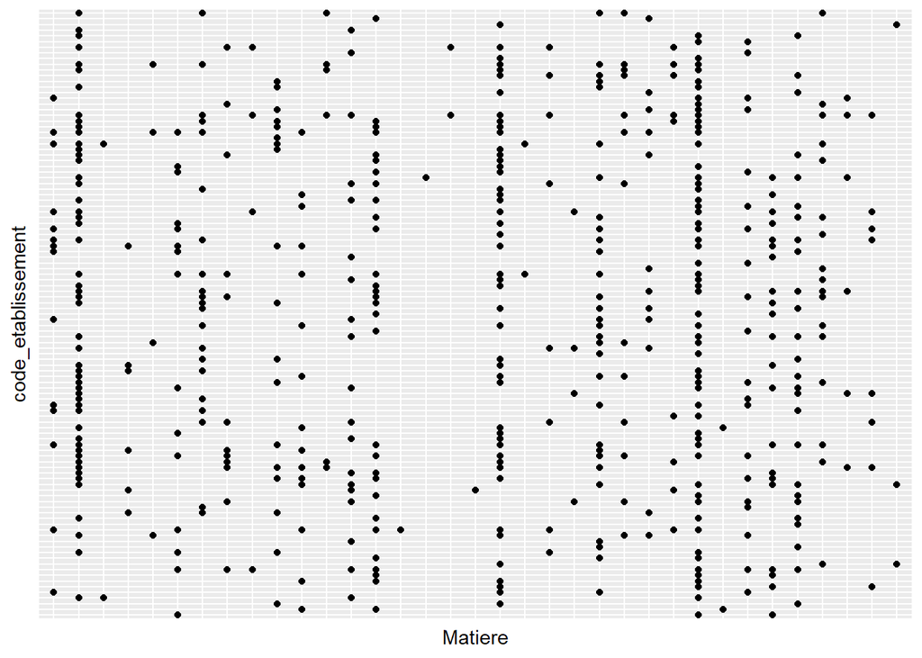

Nous voyons que les établissement ne disposent pas tous des mêmes matières et que les matières ne sont pas distribuées de la même façon dans les établissements

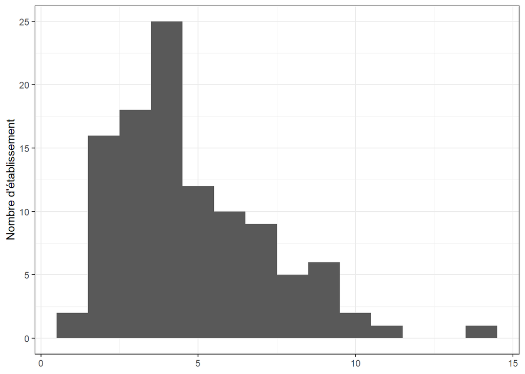

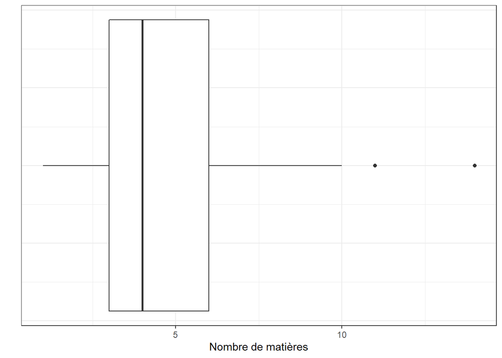

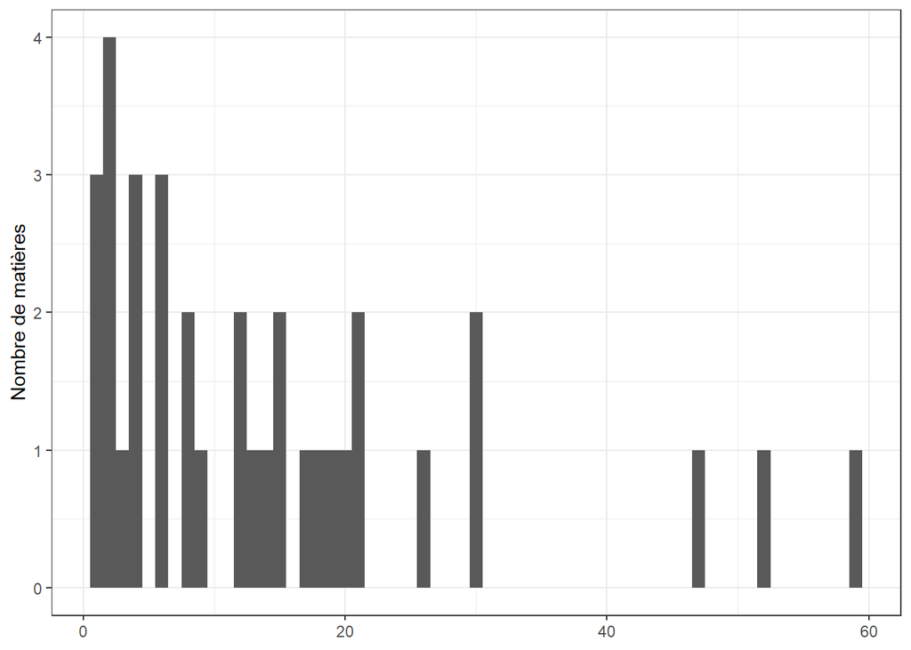

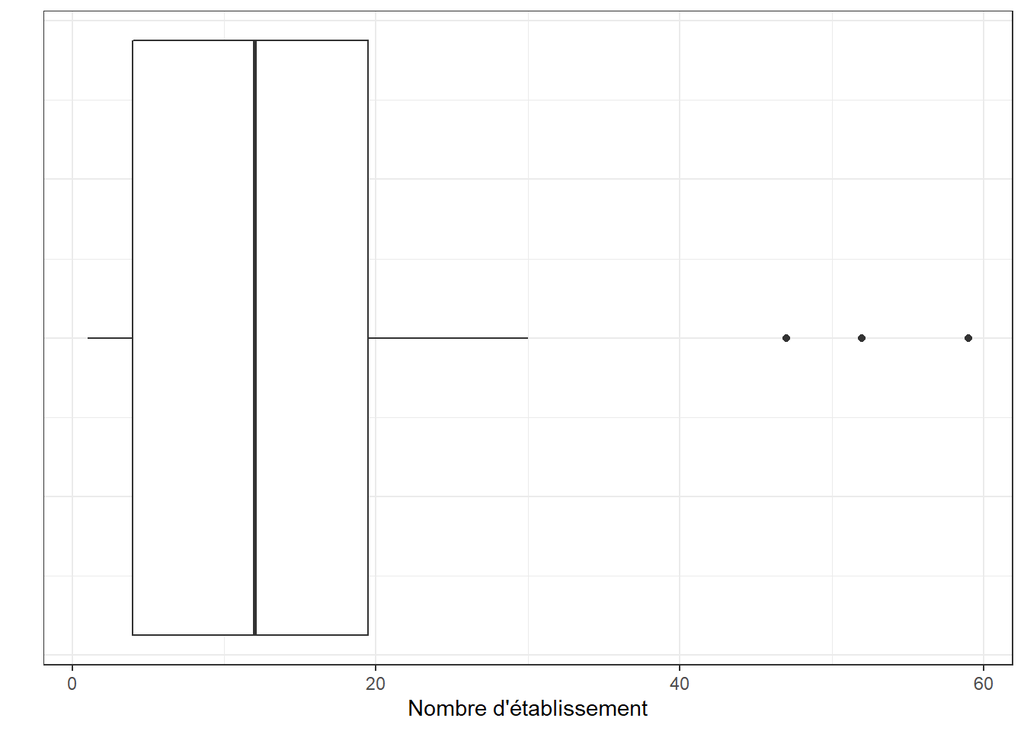

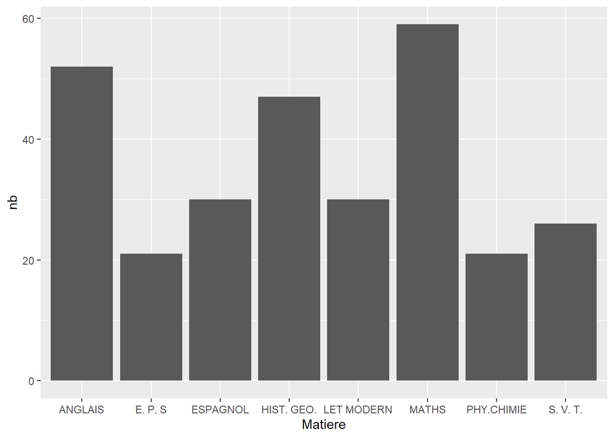

Les matières du tronc commun sont les plus représentées (top 3 = Maths, Anglais, Hist.Geo)

```
##    n
## 1 35
```

```
## [1] "ARTS PLAST"
```

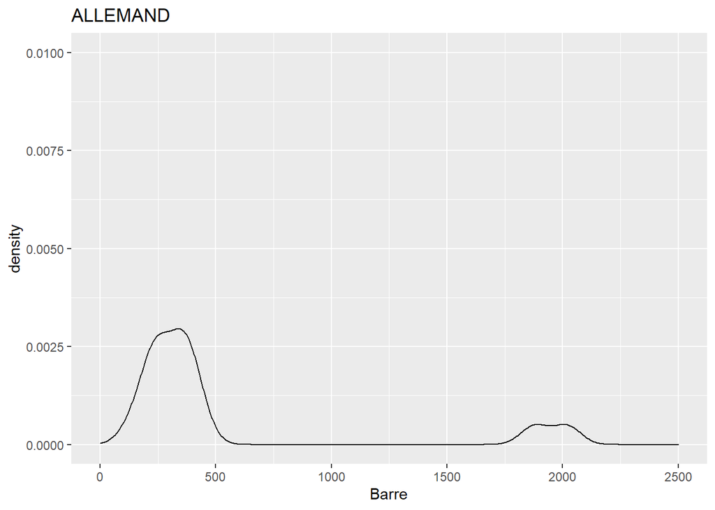

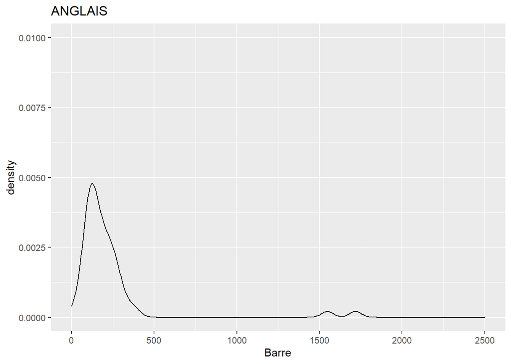

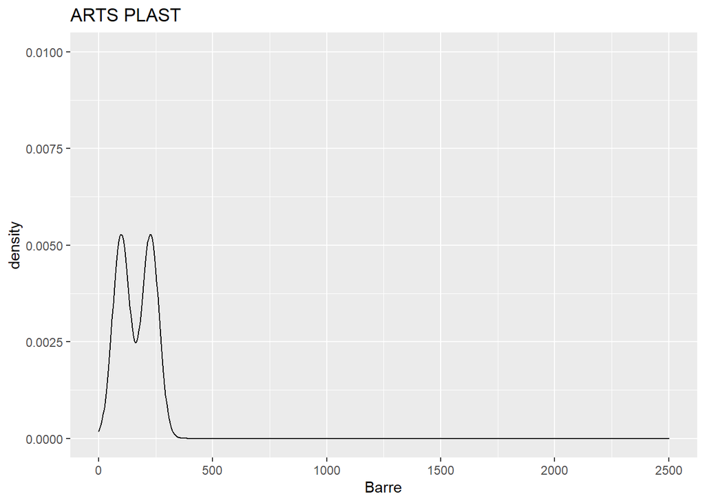

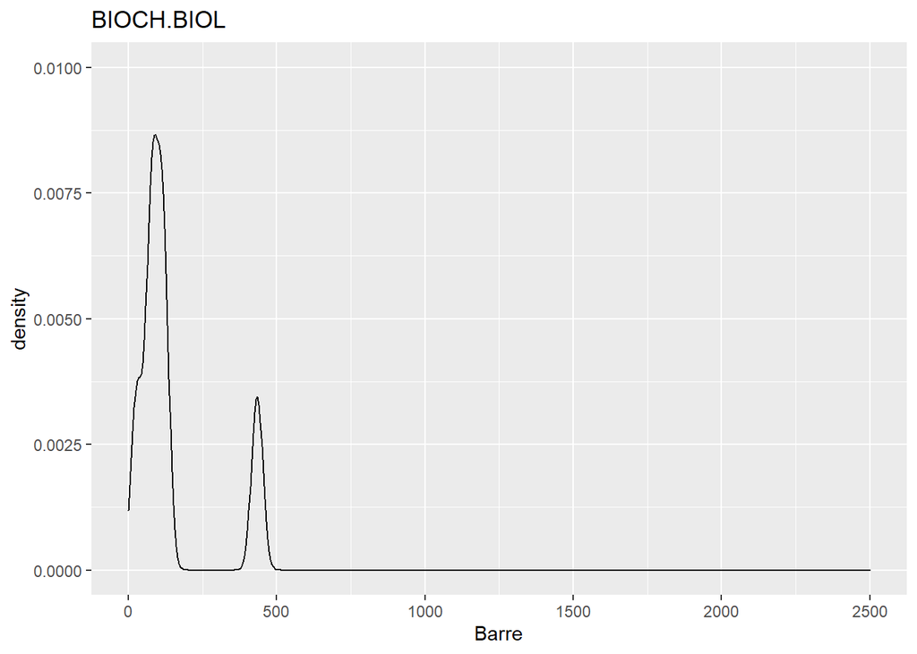

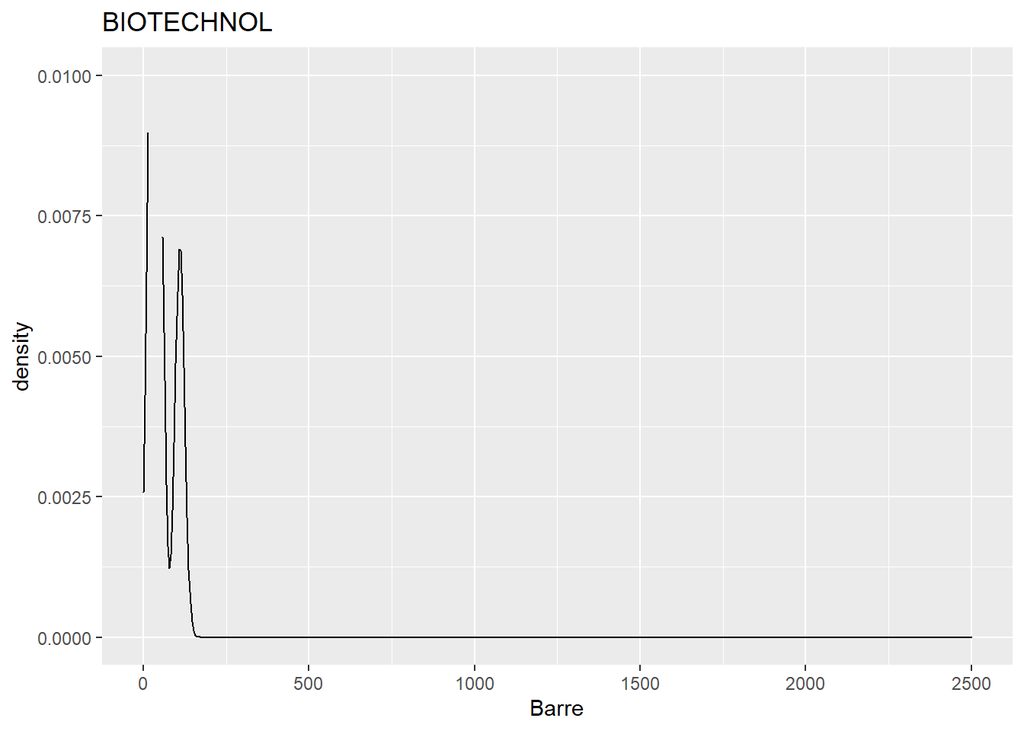

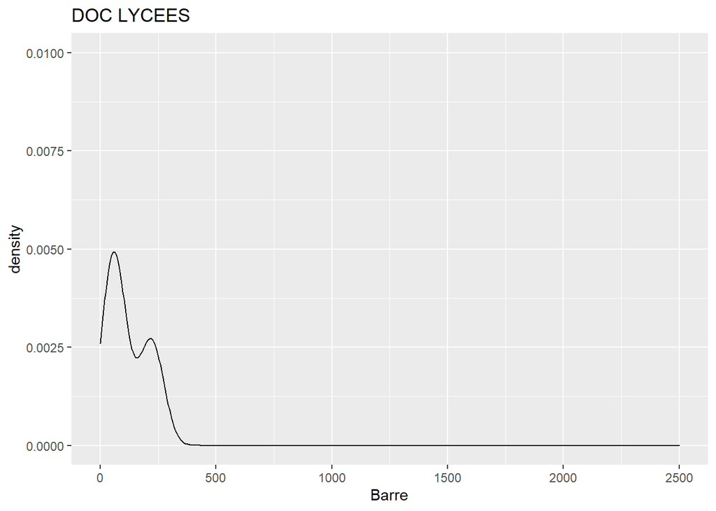

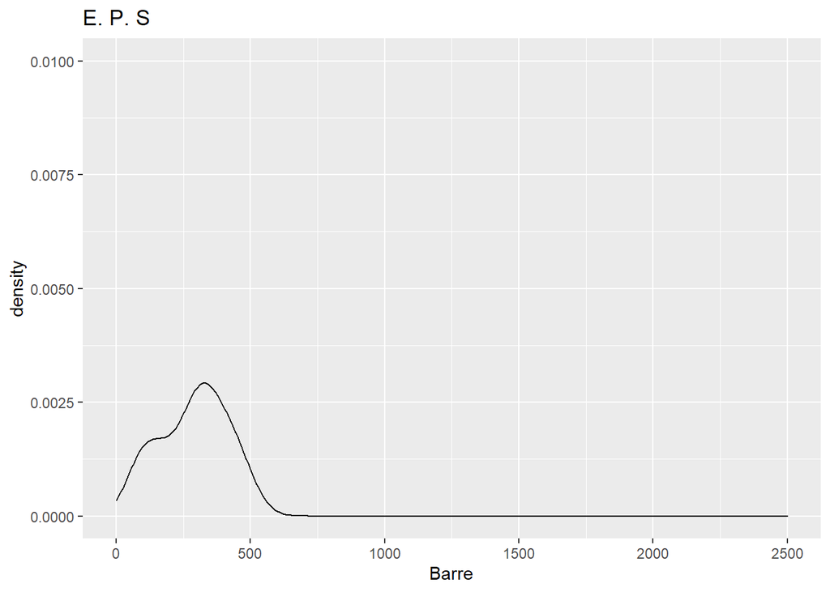

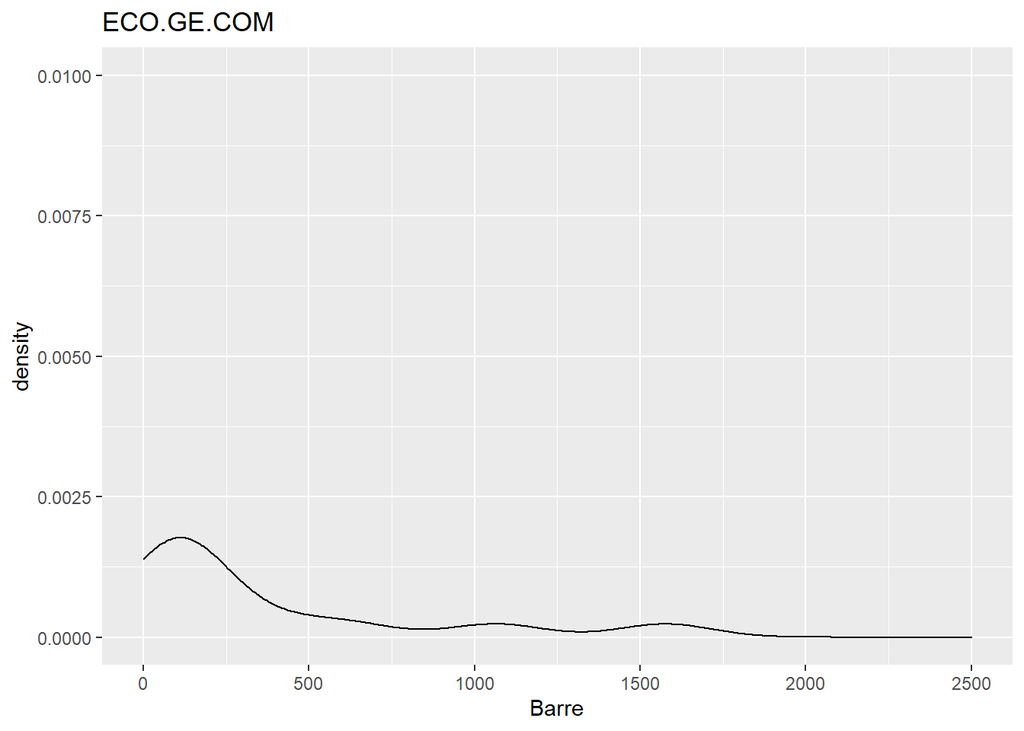

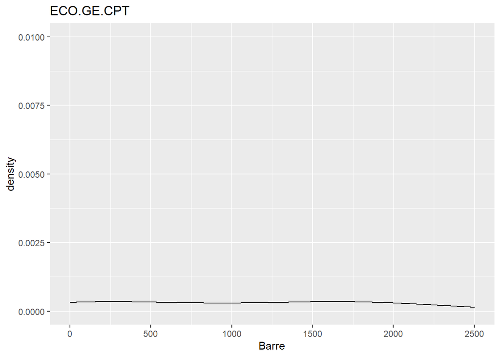

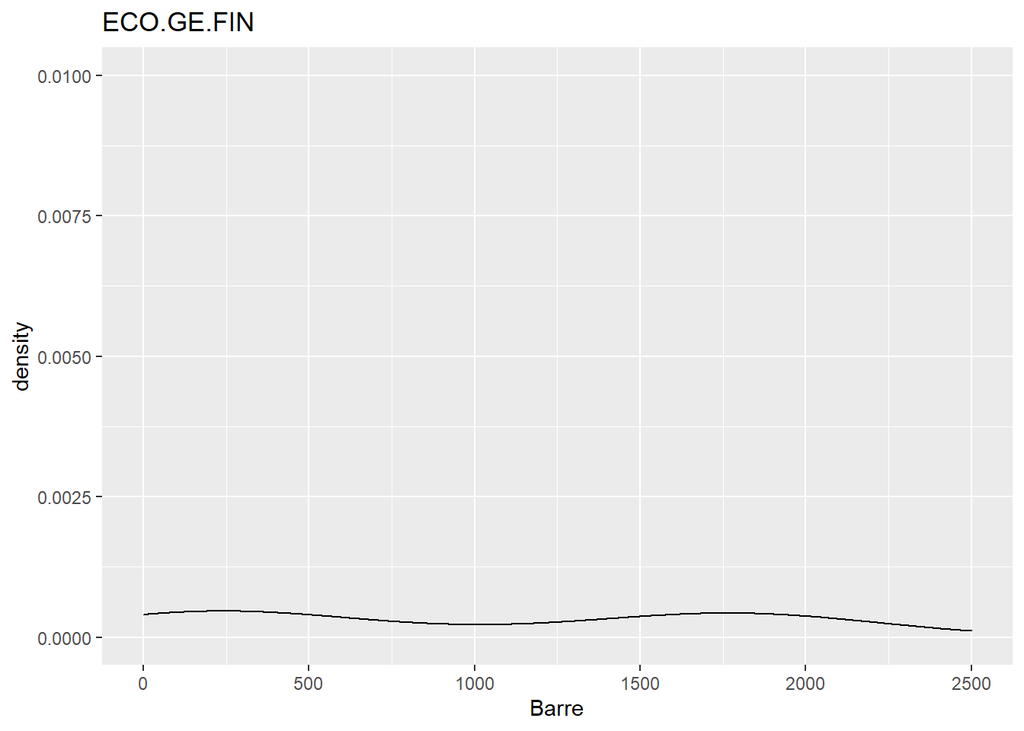

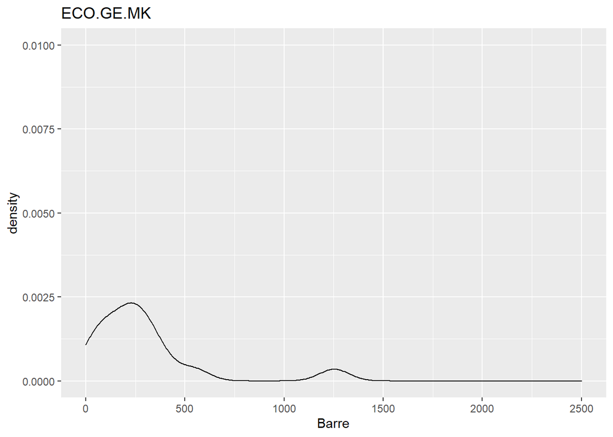

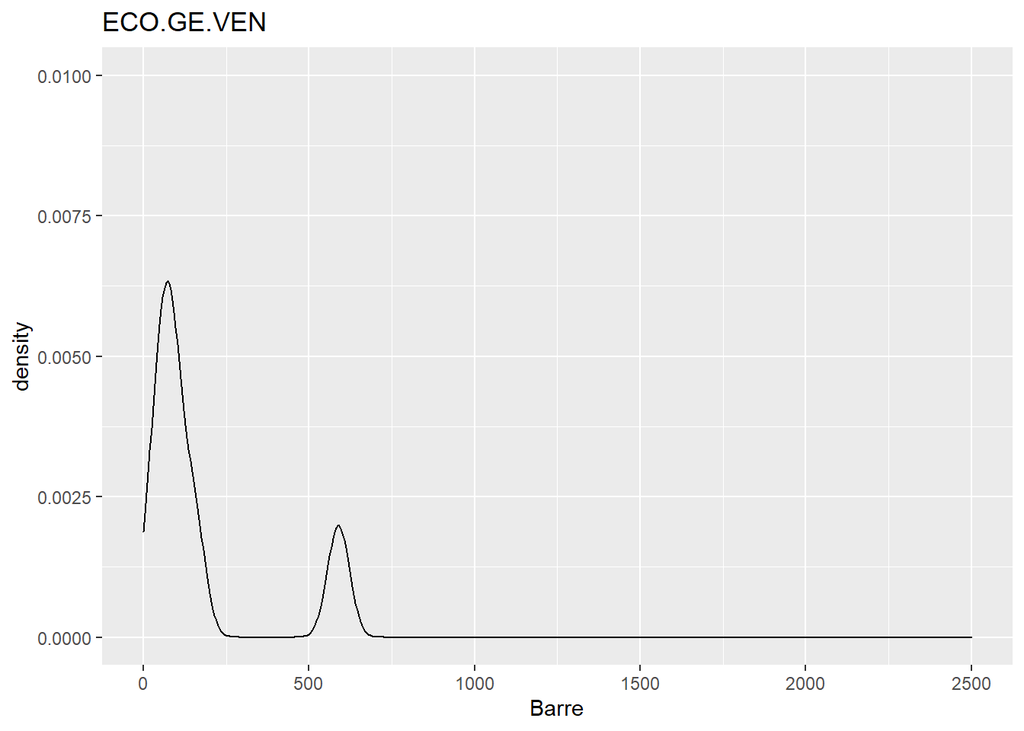

[23 more figures not shown]

On voit que pour une grande partie des matière, la distribution de barre se situe entre 0 et 500. Pour certaines matières on voit un second pic vers 1500 ou 2000 (Allemand, Math SC PH, Phy Chimie, SC Eco Soc)

# 2 Partie 1

## 2.1 Regression linéaire

Nous commençons dans un premier temps une régression linéaire classique pour tenter d’expliquer la variable Barre.

Nous observons les comportements suivant:

Modèles sans variables numériques:

- Modèle qui inclut que la variable code_etablissement Les coefficient convergent, le R square est de 0.25. Certains établissements ont un coefficient significatif (envrion 10%)
- Modèle qui inclut que la variable Matiere. Les coefficient convergent, le R square est de 0.20. De nombreuses matières ont un coefficient significatif
- Le modèle avec Matiere et code_etablissement est lui aussi significatif avec un R square de 0.40. On remarque que moins d’établissements sont significatifs

intégration des variables numériques

- le modèle avec les variables numériques et le code établissement ne converge pas pour les valeurs numériques car les valeurs numériques sont les mêmes au sein d’un même établissement
- En combinant les matière et les variables numériques nous obtenons un modèle significatif avec un R square de 0.24. Les matières sont un peu moins signifciatives que sans les variables numériques.
- le modèle avec uniquement les variables numériques est significatif mais ne donne pas un résultat très performant.

Le modèle le plus performant ici semble être celui avec Matiere et code_etablissement

## 2.2 Regression bayesienne

Pour la regression bayesienne nous décidons de nous concentrer sur les variables nuériques.

On utilise la loi a priori g de Zellner car les données à disposition et notre niveau d’expertise ne nous permettent d’inférer sur une loi à utiliser. Nous utilisons donc une loi non informative pour répondre à la problématique.

Dans un premier temps nous mesurons les coefficients

on calcul ensuite l’espérance de sigma^2

Puis nous affichons les coefficients Beta

```
## [1] "Beta 0 : -353.71"
## [1] "Beta 1 : 0.79"
## [1] "Beta 2 : 0.36"
## [1] "Beta 3 : 0.07"
## [1] "Beta 4 : 3.07"
## [1] "Beta 5 : 4.81"
## [1] "Beta 6 : 8.76"
## [1] "Beta 7 : -13.22"
## [1] "Beta 8 : 4.28"
## [1] "Beta 9 : -2.82"
## [1] "Beta 10 : 0.14"
## [1] "Beta 11 : -0.46"
## [1] "Beta 12 : 9.53"
## [1] "Beta 13 : -5.33"
## [1] "Beta 14 : -19.82"
## [1] "Beta 15 : 31.54"
## [1] "Beta 16 : -5.33"
## [1] "Beta 17 : -6.2"
```

Nous remarquons que - les coefficents Beta sont proches de ceux trouvés dans la regression linéaire. - Que les coefficients les plus élevés du modèle bayesien sont ceux qui sont le plus significatif dans le modèle linéaire.

Même si notre modèle réalise des prédictions d’une faible qualité, nous voyons que les résultats vont directionnelement dans le même sens

## 2.3 Choix des covariables

Nous allons réaliser une selection des variables dans les cas fréquentistes et bayesiens puis comparer les résultats

Dans cette partie nous démarrons du modèle avec l’ensemble des paramètres mais en excluant le code établissement

model_reg_lineaire_2 <- lm(Barre ~ # code_etablissement Matiere +effectif_presents_serie_l +effectif_presents_serie_es +effectif_presents_serie_s +taux_brut_de_reussite_serie_l +taux_brut_de_reussite_serie_es +taux_brut_de_reussite_serie_s +taux_reussite_attendu_serie_l +taux_reussite_attendu_serie_es +taux_reussite_attendu_serie_s +effectif_de_seconde+effectif_de_premiere +taux_acces_brut_seconde_bac +taux_acces_attendu_seconde_bac +taux_acces_brut_premiere_bac +taux_acces_attendu_premiere_bac +taux_brut_de_reussite_total_series +taux_reussite_attendu_total_series ,data = rawData)

### 2.3.1 Critère AIC

Voyons ce que donne un step AIC pour la sélection de modèle en fréquentiste :

Le critère AIC s’applique aux modèles estimés par une méthode du maximum de vraisemblance Le critère AIC est défini par : AIC = −2 log eL + 2k où eL est la vraisemblance maximisée et k le nombre de paramètres dans le modèle.

Avec ce critère, la déviance du modèle −2 log (eL) est pénalisée par 2 fois le nombre de paramètres.

Le meilleur modèle à selectionner est celui avec le plus petit AIC

```r
Reg_Lin_AIC <- stepAIC(model_reg_lineaire_2,  trace=FALSE)
Reg_Lin_AIC$anova
```

Ce modèle a un AIC de de 6101.372

```
##
## Call:
## lm(formula = Barre ~ taux_reussite_attendu_serie_l + taux_acces_attendu_premiere_bac,
##     data = rawData)
##
## Residuals:
##    Min     1Q Median     3Q    Max
## -377.8 -194.8 -128.0  -14.5 1701.9
##
## Coefficients:
##                                 Estimate Std. Error t value Pr(>|t|)
## (Intercept)                     -441.679    259.908  -1.699  0.08986 .
## taux_reussite_attendu_serie_l     -7.541      4.348  -1.734  0.08346 .
## taux_acces_attendu_premiere_bac   16.821      5.379   3.127  0.00187 **
## ---
## Signif. codes:  0 '***' 0.001 '**' 0.01 '*' 0.05 '.' 0.1 ' ' 1
##
## Residual standard error: 415.7 on 507 degrees of freedom
## Multiple R-squared:  0.0229, Adjusted R-squared:  0.01905
## F-statistic: 5.941 on 2 and 507 DF,  p-value: 0.002815
```

### 2.3.2 Critère BIC

Le BIC est défini par :

BIC = −2 log (eL) + k log (n).

Il est plus parcimonieux que le critère AIC puisqu’il pénalise plus le nombre de variables présentent de le modèle. Plus on maximise la vraisemblance et plus on minimise le BIC, avec une pénalité sur le nombre de paramètres : n étant le nombre d’observations et p le nombre de coefficients avec l’intercept.

```r
n <- nrow(rawData)
Reg_Lin_BIC <- stepAIC(model_reg_lineaire_2,k=log(n),  trace=FALSE)
Reg_Lin_BIC$anova
```

Le meilleur modèle selectionné est Barre ~ taux_acces_attendu_premiere_bac

Nous voyons que le modèle est plus parcimonieux que pour le critère AIC Le BIC de ce modèle est 6162.981

```
##
## Call:
## lm(formula = Barre ~ taux_acces_attendu_premiere_bac, data = rawData)
##
## Residuals:
##     Min      1Q  Median      3Q     Max
## -371.70 -197.01 -128.02  -24.55 1692.97
##
## Coefficients:
##                                 Estimate Std. Error t value Pr(>|t|)
## (Intercept)                     -453.023    260.339  -1.740  0.08244 .
## taux_acces_attendu_premiere_bac    9.169      3.084   2.973  0.00309 **
## ---
## Signif. codes:  0 '***' 0.001 '**' 0.01 '*' 0.05 '.' 0.1 ' ' 1
##
## Residual standard error: 416.5 on 508 degrees of freedom
## Multiple R-squared:  0.0171, Adjusted R-squared:  0.01517
## F-statistic: 8.839 on 1 and 508 DF,  p-value: 0.003088
```

### 2.3.3 Probabilités Postérieures

Nous passons maitenant à une selection des variables en calculant la probabilité postérieure des différents modèles.

Nous utilisons la loi informative de Zellner pour la prior sur les coefficients

Nous pouvons ainsi regarder la probabilité d’apparition des covariables

```
##
## Call:
## bas.lm(formula = Barre ~ effectif_presents_serie_l + effectif_presents_serie_es +
##     effectif_presents_serie_s + taux_brut_de_reussite_serie_l +
##     taux_brut_de_reussite_serie_es + taux_brut_de_reussite_serie_s +
##     taux_reussite_attendu_serie_l + taux_reussite_attendu_serie_es +
##     taux_reussite_attendu_serie_s + effectif_de_seconde + effectif_de_premiere +
##     taux_acces_brut_seconde_bac + taux_acces_attendu_seconde_bac +
##     taux_acces_brut_premiere_bac + taux_acces_attendu_premiere_bac +
##     taux_brut_de_reussite_total_series + taux_reussite_attendu_total_series,
##     data = rawData, prior = "g-prior", alpha = n, modelprior = uniform())
##
##
##  Marginal Posterior Inclusion Probabilities:
##                          Intercept           effectif_presents_serie_l
##                            1.00000                             0.04635
##         effectif_presents_serie_es           effectif_presents_serie_s
##                            0.04674                             0.05485
##      taux_brut_de_reussite_serie_l      taux_brut_de_reussite_serie_es
##                            0.05205                             0.09143
##      taux_brut_de_reussite_serie_s       taux_reussite_attendu_serie_l
##                            0.07592                             0.10939
##     taux_reussite_attendu_serie_es       taux_reussite_attendu_serie_s
##                            0.12186                             0.10827
##                effectif_de_seconde                effectif_de_premiere
##                            0.04443                             0.04476
##        taux_acces_brut_seconde_bac      taux_acces_attendu_seconde_bac
##                            0.07920                             0.18831
##       taux_acces_brut_premiere_bac     taux_acces_attendu_premiere_bac
##                            0.07392                             0.28841
## taux_brut_de_reussite_total_series  taux_reussite_attendu_total_series
##                            0.10307                             0.11289
```

Les variables avec la probabilité d’inclusion la plus élevée sont: - taux_acces_attendu_premiere_bac  
- taux_acces_attendu_seconde_bac  
- taux_reussite_attendu_serie_es

Nous remarquon que taux_acces_attendu_premiere_bac est la covariable la plus probable (28.8%) mais aussi la covariable présente dans les selections avec AIC et BIC

Regardons maitenant les modèles proposés

```
##                                    P(B != 0 | Y)  model 1   model 2   model 3
## Intercept                             1.00000000 1.000000 1.0000000 1.0000000
## effectif_presents_serie_l             0.04634808 0.000000 0.0000000 0.0000000
## effectif_presents_serie_es            0.04673614 0.000000 0.0000000 0.0000000
## effectif_presents_serie_s             0.05485229 0.000000 0.0000000 0.0000000
## taux_brut_de_reussite_serie_l         0.05204897 0.000000 0.0000000 0.0000000
## taux_brut_de_reussite_serie_es        0.09142749 0.000000 0.0000000 0.0000000
## taux_brut_de_reussite_serie_s         0.07591879 0.000000 0.0000000 0.0000000
## taux_reussite_attendu_serie_l         0.10939091 0.000000 0.0000000 0.0000000
## taux_reussite_attendu_serie_es        0.12185881 0.000000 0.0000000 1.0000000
## taux_reussite_attendu_serie_s         0.10827303 0.000000 0.0000000 0.0000000
## effectif_de_seconde                   0.04443096 0.000000 0.0000000 0.0000000
## effectif_de_premiere                  0.04475509 0.000000 0.0000000 0.0000000
## taux_acces_brut_seconde_bac           0.07920037 0.000000 0.0000000 0.0000000
## taux_acces_attendu_seconde_bac        0.18831112 0.000000 1.0000000 0.0000000
## taux_acces_brut_premiere_bac          0.07391601 0.000000 0.0000000 0.0000000
## taux_acces_attendu_premiere_bac       0.28841081 1.000000 0.0000000 0.0000000
## taux_brut_de_reussite_total_series    0.10307087 0.000000 0.0000000 0.0000000
## taux_reussite_attendu_total_series    0.11288632 0.000000 0.0000000 0.0000000
## BF                                            NA 1.000000 0.7092478 0.4123321
## PostProbs                                     NA 0.115900 0.0822000 0.0478000
## R2                                            NA 0.017100 0.0158000 0.0137000
## dim                                           NA 2.000000 2.0000000 2.0000000
## logmarg                                       NA 1.263495 0.9199449 0.3775690
##                                      model 4   model 5
## Intercept                          1.0000000 1.0000000
## effectif_presents_serie_l          0.0000000 0.0000000
## effectif_presents_serie_es         0.0000000 0.0000000
## effectif_presents_serie_s          0.0000000 0.0000000
## taux_brut_de_reussite_serie_l      0.0000000 0.0000000
## taux_brut_de_reussite_serie_es     0.0000000 0.0000000
## taux_brut_de_reussite_serie_s      0.0000000 0.0000000
## taux_reussite_attendu_serie_l      0.0000000 0.0000000
## taux_reussite_attendu_serie_es     0.0000000 0.0000000
## taux_reussite_attendu_serie_s      1.0000000 0.0000000
## effectif_de_seconde                0.0000000 0.0000000
## effectif_de_premiere               0.0000000 0.0000000
## taux_acces_brut_seconde_bac        0.0000000 0.0000000
## taux_acces_attendu_seconde_bac     0.0000000 0.0000000
## taux_acces_brut_premiere_bac       0.0000000 0.0000000
## taux_acces_attendu_premiere_bac    0.0000000 0.0000000
## taux_brut_de_reussite_total_series 0.0000000 1.0000000
## taux_reussite_attendu_total_series 0.0000000 0.0000000
## BF                                 0.3559867 0.3473760
## PostProbs                          0.0413000 0.0403000
## R2                                 0.0131000 0.0130000
## dim                                2.0000000 2.0000000
## logmarg                            0.2306334 0.2061477
```

Le modèle le plus proable (11.59) est le modèle avec uniquement l’intercept et la covariable taux_acces_attendu_premiere_bac. C’est donc le modèle selectionné par le critère BIC.

La probabilité du modèle peut sembler faire mais elle est à mettre en perspective avec le nombre de modèle possible et la probabilité assigné par la prior uniforme.

Etant donné qu’on a les probabilités postérieures de chaque modèle, on peut calculer le BMA - Bayesian Model Average, qui est une moyenne pondérée des différents modèles selon leur probabilité.  
Voici les coefficients selon le BMA :

```
##
##  Marginal Posterior Summaries of Coefficients:
##
##  Using  BMA
##
##  Based on the top  131072 models
##                                     post mean   post SD     post p(B != 0)
## Intercept                            3.191e+02   1.848e+01   1.000e+00
## effectif_presents_serie_l            1.685e-02   2.319e-01   4.635e-02
## effectif_presents_serie_es           7.695e-03   1.573e-01   4.674e-02
## effectif_presents_serie_s            1.412e-02   1.349e-01   5.485e-02
## taux_brut_de_reussite_serie_l        5.516e-02   4.851e-01   5.205e-02
## taux_brut_de_reussite_serie_es       2.780e-01   1.168e+00   9.143e-02
## taux_brut_de_reussite_serie_s        2.100e-01   1.178e+00   7.592e-02
## taux_reussite_attendu_serie_l       -6.598e-01   2.568e+00   1.094e-01
## taux_reussite_attendu_serie_es       5.966e-01   2.201e+00   1.219e-01
## taux_reussite_attendu_serie_s        4.294e-01   1.824e+00   1.083e-01
## effectif_de_seconde                  3.688e-04   4.201e-02   4.443e-02
## effectif_de_premiere                -8.895e-04   4.658e-02   4.476e-02
## taux_acces_brut_seconde_bac          2.357e-01   1.208e+00   7.920e-02
## taux_acces_attendu_seconde_bac       1.289e+00   3.240e+00   1.883e-01
## taux_acces_brut_premiere_bac         2.076e-01   1.655e+00   7.392e-02
## taux_acces_attendu_premiere_bac      3.329e+00   6.605e+00   2.884e-01
## taux_brut_de_reussite_total_series   4.945e-01   2.054e+00   1.031e-01
## taux_reussite_attendu_total_series   1.497e-01   3.500e+00   1.129e-01
```

On peut aussi voir la distribution postérieure de ces coefficients sous le modèle BMA (et remarquer que certains ont 0 bien au milieu de leur intervalle de crédibilité) :

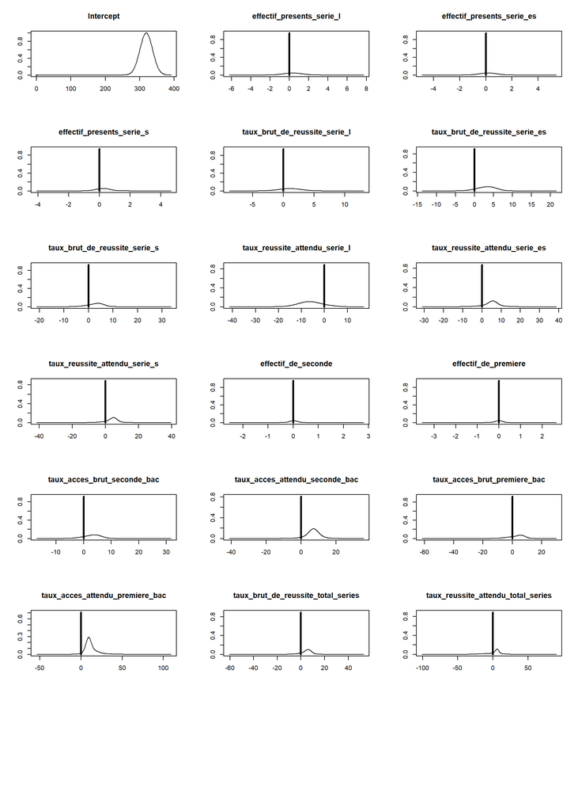

```r
# on plot les distributions de ces coefficients
par(mfrow = c(7,3))
plot(coef_Barre, ask = FALSE)
```

Nous pouvons également fournir les intervalles de crédibilité à 95% pour ces coefficients :

```
##                                             2.5%        97.5%          beta
## Intercept                          282.198837964 3.543549e+02  3.190510e+02
## effectif_presents_serie_l            0.000000000 0.000000e+00  1.684787e-02
## effectif_presents_serie_es           0.000000000 0.000000e+00  7.695471e-03
## effectif_presents_serie_s           -0.010876632 1.626679e-01  1.412020e-02
## taux_brut_de_reussite_serie_l       -0.003921500 3.703311e-01  5.515956e-02
## taux_brut_de_reussite_serie_es      -0.003346613 3.525715e+00  2.779669e-01
## taux_brut_de_reussite_serie_s        0.000000000 3.518069e+00  2.099771e-01
## taux_reussite_attendu_serie_l       -8.485984861 7.700695e-03 -6.598439e-01
## taux_reussite_attendu_serie_es       0.000000000 6.857957e+00  5.966396e-01
## taux_reussite_attendu_serie_s       -0.002143400 5.623038e+00  4.294229e-01
## effectif_de_seconde                  0.000000000 0.000000e+00  3.688486e-04
## effectif_de_premiere                 0.000000000 0.000000e+00 -8.894813e-04
## taux_acces_brut_seconde_bac         -0.012112646 3.341857e+00  2.356512e-01
## taux_acces_attendu_seconde_bac       0.000000000 9.694198e+00  1.289255e+00
## taux_acces_brut_premiere_bac        -0.424478104 3.660121e+00  2.075770e-01
## taux_acces_attendu_premiere_bac      0.000000000 1.773445e+01  3.329355e+00
## taux_brut_de_reussite_total_series   0.000000000 6.739710e+00  4.944659e-01
## taux_reussite_attendu_total_series  -0.042804192 1.012692e+01  1.496581e-01
## attr(,"Probability")
## [1] 0.95
## attr(,"class")
## [1] "confint.bas"
```

Nous voyons donc que le modèle fréquentiste et le modèle bayésien ont des similarités. En effet les deux modèles préconisent de conserver la covariables taux_acces_attendu_premiere_bac. Cependant le modèle fréquentiste basé sur AIC aure tendance à préconiser plus de variables que le mod_le bayésien.

## 2.4 Mutations en Maths et Anglais

Dans cette troisème partie nous allons faire un focus sur les mathières Maths et Anglais. L’objectif ici est de comprendre si les hypothèses trouvées au dessus sont les mêmes en fonction des matières ou si les professeurs de maths et d’anglais sont impactés par des autres variables

### 2.4.1 Maths

Dans cette partie nous allons reprendre la même structure que precedemment.

#### 2.4.1.1 regression linéaire

Nous réalisons une regression linéaire pour expliquer la variable Barre en fonction des covariables numériques pour les observations de la métière Maths.

```
##
## Call:
## lm(formula = Barre ~ effectif_presents_serie_l + effectif_presents_serie_es +
##     effectif_presents_serie_s + taux_brut_de_reussite_serie_l +
##     taux_brut_de_reussite_serie_es + taux_brut_de_reussite_serie_s +
##     taux_reussite_attendu_serie_l + taux_reussite_attendu_serie_es +
##     taux_reussite_attendu_serie_s + effectif_de_seconde + effectif_de_premiere +
##     taux_acces_brut_seconde_bac + taux_acces_attendu_seconde_bac +
##     taux_acces_brut_premiere_bac + taux_acces_attendu_premiere_bac +
##     taux_brut_de_reussite_total_series + taux_reussite_attendu_total_series,
##     data = mutations_Maths)
##
## Residuals:
##     Min      1Q  Median      3Q     Max
## -173.08  -69.00  -21.11   75.56  273.03
##
## Coefficients:
##                                    Estimate Std. Error t value Pr(>|t|)
## (Intercept)                         65.7874   489.3234   0.134   0.8937
## effectif_presents_serie_l            0.4061     1.2463   0.326   0.7462
## effectif_presents_serie_es          -0.3858     0.9616  -0.401   0.6903
## effectif_presents_serie_s            1.1721     0.8454   1.386   0.1731
## taux_brut_de_reussite_serie_l       -3.6683     2.1240  -1.727   0.0917 .
## taux_brut_de_reussite_serie_es       7.2467     4.1641   1.740   0.0893 .
## taux_brut_de_reussite_serie_s        1.4955     5.5932   0.267   0.7905
## taux_reussite_attendu_serie_l       -4.1272     5.6497  -0.731   0.4692
## taux_reussite_attendu_serie_es      -6.2008     7.1700  -0.865   0.3922
## taux_reussite_attendu_serie_s       -2.0550     8.3611  -0.246   0.8071
## effectif_de_seconde                  0.8035     0.5236   1.535   0.1325
## effectif_de_premiere                -1.4042     0.6320  -2.222   0.0319 *
## taux_acces_brut_seconde_bac         13.0976     6.2043   2.111   0.0409 *
## taux_acces_attendu_seconde_bac      -9.2312     7.2998  -1.265   0.2132
## taux_acces_brut_premiere_bac       -12.5976    10.4840  -1.202   0.2364
## taux_acces_attendu_premiere_bac      5.6413    14.9814   0.377   0.7084
## taux_brut_de_reussite_total_series   1.4551    11.0152   0.132   0.8956
## taux_reussite_attendu_total_series  11.3206    17.7198   0.639   0.5265
## ---
## Signif. codes:  0 '***' 0.001 '**' 0.01 '*' 0.05 '.' 0.1 ' ' 1
##
## Residual standard error: 116.4 on 41 degrees of freedom
## Multiple R-squared:  0.3826, Adjusted R-squared:  0.1267
## F-statistic: 1.495 on 17 and 41 DF,  p-value: 0.1451
```

Dans cette configuration:

- le taux_acces_brut_seconde_bac a un effet significatif et positif
- le effectif_de_premiere a un effet significatif et négatif

les taux_brut_de_reussite_serie_l et taux_brut_de_reussite_serie_ES ont un impact significatif mais à un seuil plus faible que les deux autres variables

#### 2.4.1.2 Selection AIC

Une selection des covariable avec la fonction step et le critère AIC nous donne le modèle suivant:

Barre ~ effectif_presents_serie_s + taux_brut_de_reussite_serie_l + taux_brut_de_reussite_serie_es + effectif_de_seconde + effectif_de_premiere + taux_acces_brut_seconde_bac

Nous retrouvons une partie des coefficients significatis de la régression.

```
##
## Call:
## lm(formula = Barre ~ effectif_presents_serie_s + taux_brut_de_reussite_serie_l +
##     taux_brut_de_reussite_serie_es + effectif_de_seconde + effectif_de_premiere +
##     taux_acces_brut_seconde_bac, data = mutations_Maths)
##
## Residuals:
##     Min      1Q  Median      3Q     Max
## -222.62  -73.59  -20.98   54.23  292.99
##
## Coefficients:
##                                Estimate Std. Error t value Pr(>|t|)
## (Intercept)                    -77.4081   182.6176  -0.424   0.6734
## effectif_presents_serie_s        0.7892     0.5009   1.575   0.1212
## taux_brut_de_reussite_serie_l   -3.9693     1.5624  -2.541   0.0141 *
## taux_brut_de_reussite_serie_es   3.8648     2.2119   1.747   0.0865 .
## effectif_de_seconde              0.6536     0.3883   1.683   0.0983 .
## effectif_de_premiere            -1.1044     0.4286  -2.576   0.0129 *
## taux_acces_brut_seconde_bac      4.2086     2.6145   1.610   0.1135
## ---
## Signif. codes:  0 '***' 0.001 '**' 0.01 '*' 0.05 '.' 0.1 ' ' 1
##
## Residual standard error: 108.2 on 52 degrees of freedom
## Multiple R-squared:  0.3242, Adjusted R-squared:  0.2462
## F-statistic: 4.157 on 6 and 52 DF,  p-value: 0.001744
```

#### 2.4.1.3 Selection BIC

Le modèle optimal selon ce critère ne dispose que d’une seule covariable

Barre ~ taux_brut_de_reussite_serie_es

```
##
## Call:
## lm(formula = Barre ~ taux_brut_de_reussite_serie_es, data = mutations_Maths)
##
## Residuals:
##     Min      1Q  Median      3Q     Max
## -145.97  -80.44  -34.60   60.41  375.63
##
## Coefficients:
##                                Estimate Std. Error t value Pr(>|t|)
## (Intercept)                    -286.357    148.068  -1.934  0.05809 .
## taux_brut_de_reussite_serie_es    5.433      1.688   3.220  0.00212 **
## ---
## Signif. codes:  0 '***' 0.001 '**' 0.01 '*' 0.05 '.' 0.1 ' ' 1
##
## Residual standard error: 115.6 on 57 degrees of freedom
## Multiple R-squared:  0.1539, Adjusted R-squared:  0.139
## F-statistic: 10.37 on 1 and 57 DF,  p-value: 0.00212
```

#### 2.4.1.4 Probabilités Postérieures

Nous reprenons la mêmme démarche que pour la question 2 à savoir une prior de Zellner

```
##
## Call:
## bas.lm(formula = Barre ~ effectif_presents_serie_l + effectif_presents_serie_es +
##     effectif_presents_serie_s + taux_brut_de_reussite_serie_l +
##     taux_brut_de_reussite_serie_es + taux_brut_de_reussite_serie_s +
##     taux_reussite_attendu_serie_l + taux_reussite_attendu_serie_es +
##     taux_reussite_attendu_serie_s + effectif_de_seconde + effectif_de_premiere +
##     taux_acces_brut_seconde_bac + taux_acces_attendu_seconde_bac +
##     taux_acces_brut_premiere_bac + taux_acces_attendu_premiere_bac +
##     taux_brut_de_reussite_total_series + taux_reussite_attendu_total_series,
##     data = mutations_Maths, prior = "g-prior", alpha = n, modelprior = uniform())
##
##
##  Marginal Posterior Inclusion Probabilities:
##                          Intercept           effectif_presents_serie_l
##                             1.0000                              0.1278
##         effectif_presents_serie_es           effectif_presents_serie_s
##                             0.1336                              0.2247
##      taux_brut_de_reussite_serie_l      taux_brut_de_reussite_serie_es
##                             0.5341                              0.5446
##      taux_brut_de_reussite_serie_s       taux_reussite_attendu_serie_l
##                             0.1375                              0.1309
##     taux_reussite_attendu_serie_es       taux_reussite_attendu_serie_s
##                             0.1422                              0.1530
##                effectif_de_seconde                effectif_de_premiere
##                             0.1709                              0.2325
##        taux_acces_brut_seconde_bac      taux_acces_attendu_seconde_bac
##                             0.1634                              0.1428
##       taux_acces_brut_premiere_bac     taux_acces_attendu_premiere_bac
##                             0.2334                              0.2616
## taux_brut_de_reussite_total_series  taux_reussite_attendu_total_series
##                             0.1849                              0.1560
```

```
##                                    P(B != 0 | Y)  model 1   model 2   model 3
## Intercept                              1.0000000 1.000000 1.0000000 1.0000000
## effectif_presents_serie_l              0.1278411 0.000000 0.0000000 0.0000000
## effectif_presents_serie_es             0.1336379 0.000000 0.0000000 0.0000000
## effectif_presents_serie_s              0.2247180 0.000000 0.0000000 0.0000000
## taux_brut_de_reussite_serie_l          0.5341042 0.000000 1.0000000 1.0000000
## taux_brut_de_reussite_serie_es         0.5445978 1.000000 1.0000000 0.0000000
## taux_brut_de_reussite_serie_s          0.1374716 0.000000 0.0000000 0.0000000
## taux_reussite_attendu_serie_l          0.1308971 0.000000 0.0000000 0.0000000
## taux_reussite_attendu_serie_es         0.1422481 0.000000 0.0000000 0.0000000
## taux_reussite_attendu_serie_s          0.1530191 0.000000 0.0000000 0.0000000
## effectif_de_seconde                    0.1709381 0.000000 0.0000000 0.0000000
## effectif_de_premiere                   0.2324745 0.000000 0.0000000 0.0000000
## taux_acces_brut_seconde_bac            0.1633565 0.000000 0.0000000 0.0000000
## taux_acces_attendu_seconde_bac         0.1427613 0.000000 0.0000000 0.0000000
## taux_acces_brut_premiere_bac           0.2334267 0.000000 0.0000000 1.0000000
## taux_acces_attendu_premiere_bac        0.2615769 0.000000 0.0000000 0.0000000
## taux_brut_de_reussite_total_series     0.1848768 0.000000 0.0000000 0.0000000
## taux_reussite_attendu_total_series     0.1559873 0.000000 0.0000000 0.0000000
## BF                                            NA 1.000000 0.7943572 0.5049619
## PostProbs                                     NA 0.026200 0.0208000 0.0132000
## R2                                            NA 0.153900 0.2063000 0.1935000
## dim                                           NA 2.000000 3.0000000 3.0000000
## logmarg                                       NA 2.710723 2.4805010 2.0274507
##                                      model 4   model 5
## Intercept                          1.0000000 1.0000000
## effectif_presents_serie_l          0.0000000 0.0000000
## effectif_presents_serie_es         0.0000000 0.0000000
## effectif_presents_serie_s          0.0000000 0.0000000
## taux_brut_de_reussite_serie_l      1.0000000 0.0000000
## taux_brut_de_reussite_serie_es     1.0000000 0.0000000
## taux_brut_de_reussite_serie_s      0.0000000 0.0000000
## taux_reussite_attendu_serie_l      0.0000000 0.0000000
## taux_reussite_attendu_serie_es     0.0000000 0.0000000
## taux_reussite_attendu_serie_s      0.0000000 0.0000000
## effectif_de_seconde                0.0000000 0.0000000
## effectif_de_premiere               0.0000000 0.0000000
## taux_acces_brut_seconde_bac        0.0000000 0.0000000
## taux_acces_attendu_seconde_bac     0.0000000 0.0000000
## taux_acces_brut_premiere_bac       1.0000000 0.0000000
## taux_acces_attendu_premiere_bac    0.0000000 1.0000000
## taux_brut_de_reussite_total_series 0.0000000 0.0000000
## taux_reussite_attendu_total_series 0.0000000 0.0000000
## BF                                 0.3187095 0.3068083
## PostProbs                          0.0083000 0.0080000
## R2                                 0.2374000 0.1180000
## dim                                4.0000000 2.0000000
## logmarg                            1.5672476 1.5291909
```

Le meilleur modèle est composé des mêmes variables que la selection avec le critère du BIC

Le second modèle est lui composé de la variable taux_brut_de_reussite_serie_es et de la covariable taux_brut_de_reussite_serie_l.

Il semblerait que la fillière S a peu d’impact dans le choix des professeurs pour rejoindre un établissement.

```
##
##  Marginal Posterior Summaries of Coefficients:
##
##  Using  BMA
##
##  Based on the top  131072 models
##                                     post mean   post SD     post p(B != 0)
## Intercept                           187.901695   15.123473    1.000000
## effectif_presents_serie_l            -0.041085    0.361193    0.127841
## effectif_presents_serie_es           -0.032467    0.302446    0.133638
## effectif_presents_serie_s             0.151731    0.414221    0.224718
## taux_brut_de_reussite_serie_l        -1.852155    2.137276    0.534104
## taux_brut_de_reussite_serie_es        2.752286    3.082660    0.544598
## taux_brut_de_reussite_serie_s        -0.109767    1.320467    0.137472
## taux_reussite_attendu_serie_l        -0.172630    1.543639    0.130897
## taux_reussite_attendu_serie_es       -0.006257    1.960651    0.142248
## taux_reussite_attendu_serie_s        -0.364107    2.139698    0.153019
## effectif_de_seconde                   0.046855    0.211608    0.170938
## effectif_de_premiere                 -0.100836    0.282917    0.232474
## taux_acces_brut_seconde_bac           0.393654    1.722239    0.163357
## taux_acces_attendu_seconde_bac       -0.170901    2.094104    0.142761
## taux_acces_brut_premiere_bac          1.298515    3.475682    0.233427
## taux_acces_attendu_premiere_bac       2.351998    5.656682    0.261577
## taux_brut_de_reussite_total_series    0.723065    2.788849    0.184877
## taux_reussite_attendu_total_series    0.239651    3.238647    0.155987
```

Les coefficients calculés sur l’ensemble des modèles pondérés par leurs probabilité permet de voir que le taux_brut_de_reussite_serie_es a un impact positif sur Barre alors que taux_brut_de_reussite_serie_l a un taux négatif

### 2.4.2 Anglais

Reprenons la même démarche pour la matiere => Anglais

#### 2.4.2.1 Regression linéaire

Réalisons maintenant une régression linéaire pour l’Anglais, avec l’ensemble des variables excepté le code établissement, l’établissement, la ville, la commune :

```
##
## Call:
## lm(formula = Barre ~ effectif_presents_serie_l + effectif_presents_serie_es +
##     effectif_presents_serie_s + taux_brut_de_reussite_serie_l +
##     taux_brut_de_reussite_serie_es + taux_brut_de_reussite_serie_s +
##     taux_reussite_attendu_serie_l + taux_reussite_attendu_serie_es +
##     taux_reussite_attendu_serie_s + effectif_de_seconde + effectif_de_premiere +
##     taux_acces_brut_seconde_bac + taux_acces_attendu_seconde_bac +
##     taux_acces_brut_premiere_bac + taux_acces_attendu_premiere_bac +
##     taux_brut_de_reussite_total_series + taux_reussite_attendu_total_series,
##     data = mutations_Anglais)
##
## Residuals:
##     Min      1Q  Median      3Q     Max
## -363.03 -133.21  -24.75   97.93 1044.32
##
## Coefficients:
##                                      Estimate Std. Error t value Pr(>|t|)
## (Intercept)                        -1286.4382  1860.5131  -0.691   0.4940
## effectif_presents_serie_l             -5.2435     5.6318  -0.931   0.3584
## effectif_presents_serie_es            -1.6538     2.7501  -0.601   0.5516
## effectif_presents_serie_s              0.7911     2.3383   0.338   0.7372
## taux_brut_de_reussite_serie_l         -5.1155     5.8121  -0.880   0.3850
## taux_brut_de_reussite_serie_es         5.9949     8.9053   0.673   0.5054
## taux_brut_de_reussite_serie_s          3.0029    14.7626   0.203   0.8400
## taux_reussite_attendu_serie_l         -3.7900    19.4963  -0.194   0.8470
## taux_reussite_attendu_serie_es        30.9369    17.5094   1.767   0.0862 .
## taux_reussite_attendu_serie_s        -24.6363    20.1117  -1.225   0.2290
## effectif_de_seconde                    1.2467     1.5277   0.816   0.4202
## effectif_de_premiere                  -1.0171     1.9638  -0.518   0.6079
## taux_acces_brut_seconde_bac            8.7706    13.6909   0.641   0.5261
## taux_acces_attendu_seconde_bac       -30.4301    23.0086  -1.323   0.1948
## taux_acces_brut_premiere_bac         -42.0258    25.2706  -1.663   0.1055
## taux_acces_attendu_premiere_bac      103.0319    52.3436   1.968   0.0572 .
## taux_brut_de_reussite_total_series    32.8251    31.4412   1.044   0.3038
## taux_reussite_attendu_total_series   -62.3386    54.2693  -1.149   0.2587
## ---
## Signif. codes:  0 '***' 0.001 '**' 0.01 '*' 0.05 '.' 0.1 ' ' 1
##
## Residual standard error: 287.9 on 34 degrees of freedom
## Multiple R-squared:  0.3659, Adjusted R-squared:  0.0489
## F-statistic: 1.154 on 17 and 34 DF,  p-value: 0.3492
```

Les variables taux_acces_attendu_premiere_bac et taux_reussite_attendu_serie_es sont significatif au seil de 90%.

#### 2.4.2.2 Selection AIC

Le meilleur modèle obtenu est beaucoup plus complet que dans l’ensemble des modèlisation précédentes.

Barre ~ effectif_presents_serie_l + taux_brut_de_reussite_serie_l + taux_reussite_attendu_serie_es + taux_reussite_attendu_serie_s + taux_acces_attendu_seconde_bac + taux_acces_brut_premiere_bac + taux_acces_attendu_premiere_bac + taux_brut_de_reussite_total_series + taux_reussite_attendu_total_series

```
##
## Call:
## lm(formula = Barre ~ effectif_presents_serie_l + taux_brut_de_reussite_serie_l +
##     taux_reussite_attendu_serie_es + taux_reussite_attendu_serie_s +
##     taux_acces_attendu_seconde_bac + taux_acces_brut_premiere_bac +
##     taux_acces_attendu_premiere_bac + taux_brut_de_reussite_total_series +
##     taux_reussite_attendu_total_series, data = mutations_Anglais)
##
## Residuals:
##    Min     1Q Median     3Q    Max
## -420.1 -116.3  -33.2   88.1 1089.2
##
## Coefficients:
##                                     Estimate Std. Error t value Pr(>|t|)
## (Intercept)                        -1696.950    822.088  -2.064  0.04521 *
## effectif_presents_serie_l             -3.095      2.219  -1.395  0.17038
## taux_brut_de_reussite_serie_l         -6.030      4.225  -1.427  0.16087
## taux_reussite_attendu_serie_es        37.414     13.888   2.694  0.01010 *
## taux_reussite_attendu_serie_s        -26.011     15.296  -1.700  0.09643 .
## taux_acces_attendu_seconde_bac       -26.632     15.037  -1.771  0.08381 .
## taux_acces_brut_premiere_bac         -29.358     16.041  -1.830  0.07432 .
## taux_acces_attendu_premiere_bac      101.217     34.272   2.953  0.00513 **
## taux_brut_de_reussite_total_series    44.714     17.511   2.553  0.01439 *
## taux_reussite_attendu_total_series   -74.814     32.156  -2.327  0.02488 *
## ---
## Signif. codes:  0 '***' 0.001 '**' 0.01 '*' 0.05 '.' 0.1 ' ' 1
##
## Residual standard error: 269.3 on 42 degrees of freedom
## Multiple R-squared:  0.3146, Adjusted R-squared:  0.1677
## F-statistic: 2.142 on 9 and 42 DF,  p-value: 0.04689
```

#### 2.4.2.3 Selection BIC

Selon le critère du BIC, le modèle ne dépend que de l’intercept. Cela veut dire que selon ce critère, aucune des variables n’a d’impact sur la variable Barre

#### 2.4.2.4 Probabilités Postérieures

regardons les probabilités postérieures

```
##                                    P(B != 0 | Y) model 1    model 2    model 3
## Intercept                              1.0000000  1.0000  1.0000000  1.0000000
## effectif_presents_serie_l              0.1692760  0.0000  0.0000000  0.0000000
## effectif_presents_serie_es             0.1416279  0.0000  0.0000000  0.0000000
## effectif_presents_serie_s              0.1561913  0.0000  0.0000000  0.0000000
## taux_brut_de_reussite_serie_l          0.1982108  0.0000  0.0000000  0.0000000
## taux_brut_de_reussite_serie_es         0.5480557  0.0000  1.0000000  1.0000000
## taux_brut_de_reussite_serie_s          0.1567957  0.0000  0.0000000  0.0000000
## taux_reussite_attendu_serie_l          0.2400166  0.0000  1.0000000  0.0000000
## taux_reussite_attendu_serie_es         0.1666302  0.0000  0.0000000  0.0000000
## taux_reussite_attendu_serie_s          0.2920652  0.0000  0.0000000  0.0000000
## effectif_de_seconde                    0.1557311  0.0000  0.0000000  0.0000000
## effectif_de_premiere                   0.2036110  0.0000  0.0000000  0.0000000
## taux_acces_brut_seconde_bac            0.1745787  0.0000  0.0000000  0.0000000
## taux_acces_attendu_seconde_bac         0.1629829  0.0000  0.0000000  0.0000000
## taux_acces_brut_premiere_bac           0.1690304  0.0000  0.0000000  0.0000000
## taux_acces_attendu_premiere_bac        0.2896512  0.0000  0.0000000  0.0000000
## taux_brut_de_reussite_total_series     0.1633465  0.0000  0.0000000  0.0000000
## taux_reussite_attendu_total_series     0.2123437  0.0000  0.0000000  0.0000000
## BF                                            NA  1.0000  0.4704795  0.3383719
## PostProbs                                     NA  0.0256  0.0121000  0.0087000
## R2                                            NA  0.0000  0.1208000  0.0354000
## dim                                           NA  1.0000  3.0000000  2.0000000
## logmarg                                       NA  0.0000 -0.7540029 -1.0836097
##                                       model 4    model 5
## Intercept                           1.0000000  1.0000000
## effectif_presents_serie_l           0.0000000  0.0000000
## effectif_presents_serie_es          0.0000000  0.0000000
## effectif_presents_serie_s           0.0000000  0.0000000
## taux_brut_de_reussite_serie_l       0.0000000  0.0000000
## taux_brut_de_reussite_serie_es      1.0000000  1.0000000
## taux_brut_de_reussite_serie_s       0.0000000  0.0000000
## taux_reussite_attendu_serie_l       0.0000000  0.0000000
## taux_reussite_attendu_serie_es      0.0000000  0.0000000
## taux_reussite_attendu_serie_s       1.0000000  0.0000000
## effectif_de_seconde                 0.0000000  0.0000000
## effectif_de_premiere                0.0000000  0.0000000
## taux_acces_brut_seconde_bac         0.0000000  1.0000000
## taux_acces_attendu_seconde_bac      0.0000000  0.0000000
## taux_acces_brut_premiere_bac        0.0000000  0.0000000
## taux_acces_attendu_premiere_bac     0.0000000  0.0000000
## taux_brut_de_reussite_total_series  0.0000000  0.0000000
## taux_reussite_attendu_total_series  0.0000000  0.0000000
## BF                                  0.2995647  0.2524148
## PostProbs                           0.0077000  0.0065000
## R2                                  0.1047000  0.0986000
## dim                                 3.0000000  3.0000000
## logmarg                            -1.2054249 -1.3766817
```

Le premier modèle est celui trouvé par le critère BIC. Le second modèle intégre lui les variables: - taux_brut_de_reussite_serie_es - taux_reussite_attendu_serie_l

```
##
##  Marginal Posterior Summaries of Coefficients:
##
##  Using  BMA
##
##  Based on the top  131072 models
##                                     post mean  post SD    post p(B != 0)
## Intercept                           226.48077   40.36261    1.00000
## effectif_presents_serie_l            -0.39229    1.60762    0.16928
## effectif_presents_serie_es           -0.09769    0.78501    0.14163
## effectif_presents_serie_s             0.13083    0.72569    0.15619
## taux_brut_de_reussite_serie_l        -0.81033    2.44334    0.19821
## taux_brut_de_reussite_serie_es        5.56415    6.29286    0.54806
## taux_brut_de_reussite_serie_s        -0.53926    3.93925    0.15680
## taux_reussite_attendu_serie_l        -2.70015    6.93591    0.24002
## taux_reussite_attendu_serie_es        1.28200    6.46882    0.16663
## taux_reussite_attendu_serie_s        -5.11388   11.06589    0.29207
## effectif_de_seconde                   0.02631    0.37572    0.15573
## effectif_de_premiere                 -0.14347    0.49367    0.20361
## taux_acces_brut_seconde_bac          -0.97286    3.85811    0.17458
## taux_acces_attendu_seconde_bac       -1.37238    7.31139    0.16298
## taux_acces_brut_premiere_bac         -1.62361    7.20345    0.16903
## taux_acces_attendu_premiere_bac      10.70944   24.31579    0.28965
## taux_brut_de_reussite_total_series    1.33643    7.78834    0.16335
## taux_reussite_attendu_total_series   -4.24214   17.22586    0.21234
```

Les coefficients calculés sur l’ensemble des modèles pondérés par leurs probabilité permet de voir que le taux_reussite_attendu_serie_l a un impact négatif sur Barre alors que le taux_brut_de_reussite_serie_es a un impact positif sur Barre

### 2.4.3 Conclusion

Nous voyons que les covariables agissent de manière différente dans les deux disciplines; En effet les variables qui ont le plus d’impact et ont la plus grande probabilité d’apparaitre dans les modèles finaux sont différentes entre la simulation réalisée pour les maths et celle réalisée pour l’anglais.

# 3 Loi de Pareto

On ignore maintenant les covariables, et on s’intéresse uniquement à la loi du nombre de points nécessaire (colonne Barre) en se basant sur une loi de Pareto

## 3.1 Package R permettant de générer des réalisations d’une loi de Pareto

```
## Using  as id variables
```

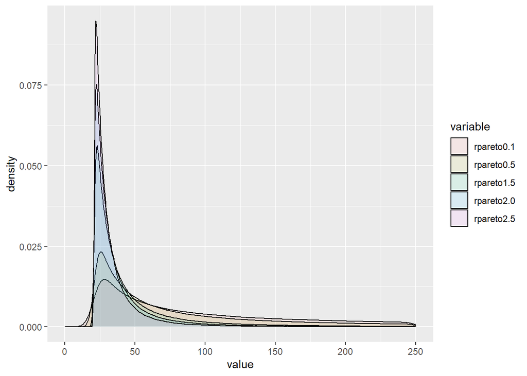

Le graphique ci dessus nos montre que plus le alpha est grand, plus les données sont concentrées.

## 3.2 Loi a priori pour $\alpha$.

regardons dans un premier temps la distribution de Barre

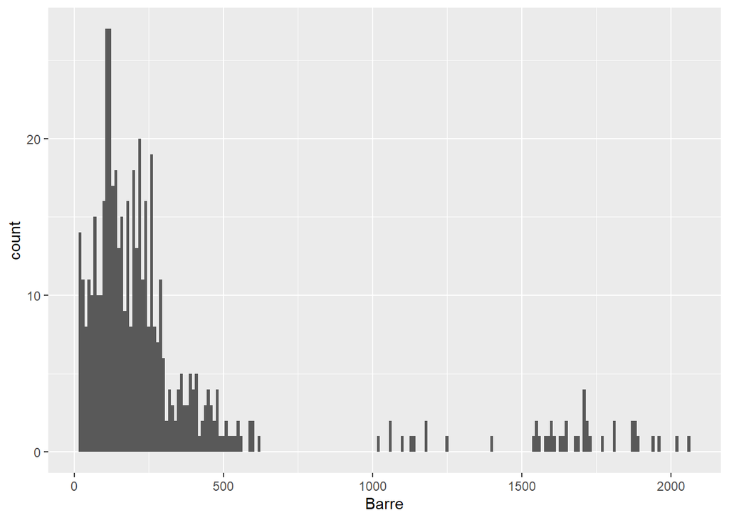

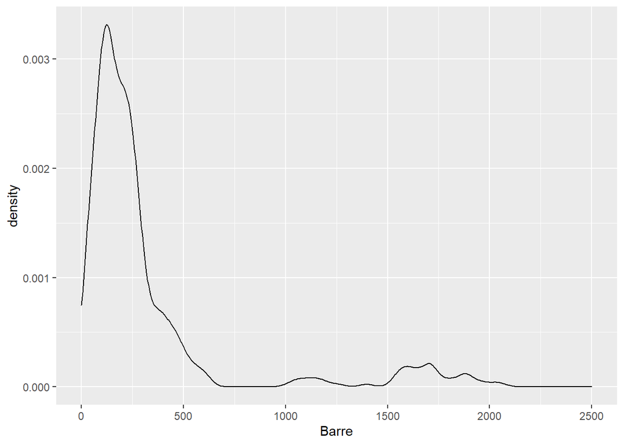

COmparons là ensuite aux simulations réalisées au dessus.

```
## Using  as id variables
```

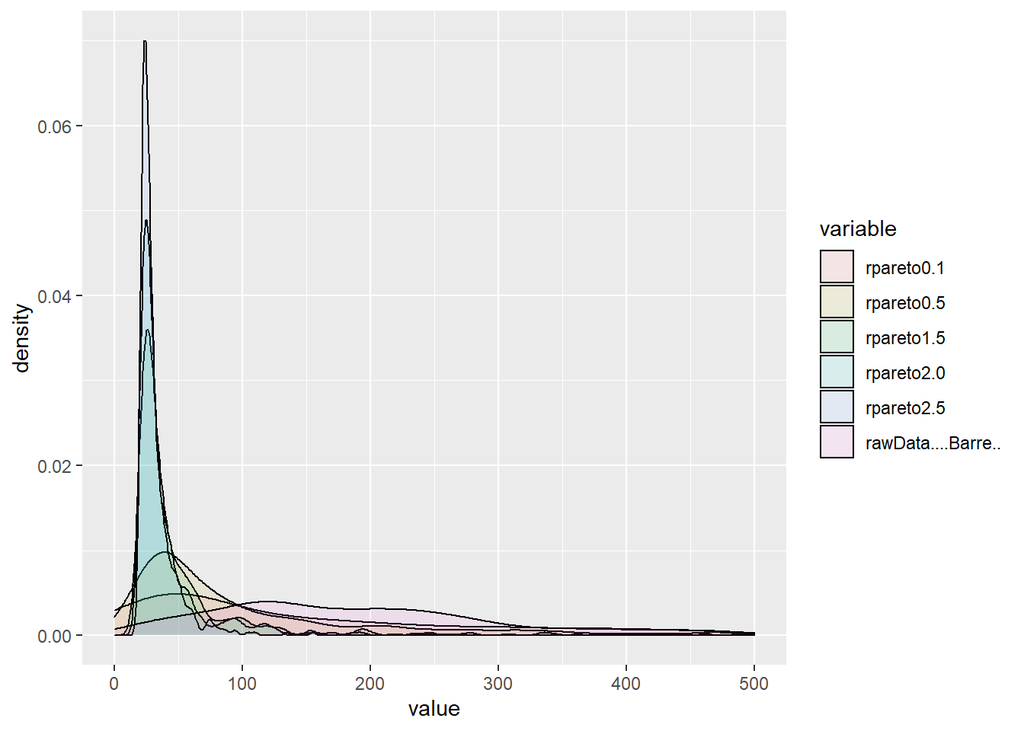

Nous voyons que la distributions de barre est assez étendue. Le paramètre m devrait donc être assez élevé.

Pour selectionner la prior nous prenons une loi qui semble s’apparenter à la distribution de la variable Barre. Nous décidons de partir sur une loi normale de moyenne 140 et d’écart type 120. Les deux distributions semblent proches

Les deux distributions semblent très proches dans R+

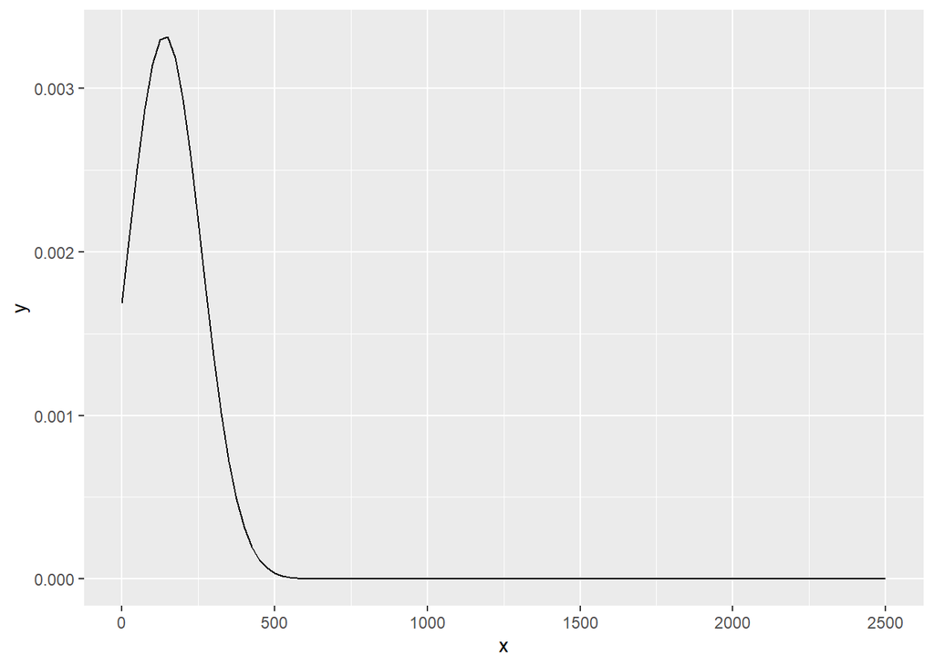

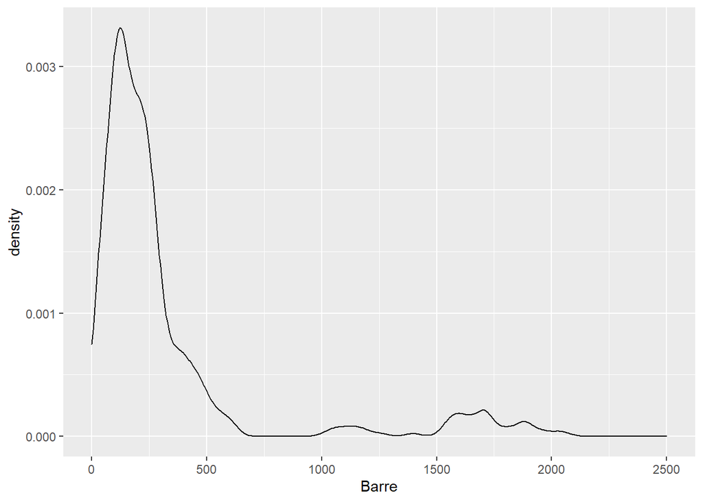